# Figure 3: Juxtaspinal mitochondrial ultrastructure

# Fig 3D

Inner mitochondrial membrane (IMM) surface area in reconstructed juxtaspinal mitochondrial regions.

**Source data**  
`Fig 3D, E.csv`

**Columns**

- `Date` — Experiment date
- `Condition` — Control or TTX
- `Mito` — Mitochondrial reconstruction ID
- `IMM_surf_um2` — Inner mitochondrial membrane surface area (µm²)

## Data

```r
condition_order <- c("Control", "TTX")
spacing_map <- c("Control" = 1, "TTX" = 2.2)

Density <- read_csv("./Fig 3D, E.csv", show_col_types = FALSE) %>%
  filter(Condition %in% condition_order) %>%
  mutate(
    Condition = factor(Condition, levels = condition_order),
    Date = factor(trimws(as.character(Date))),
    IMM_surf_um2 = as.numeric(IMM_surf_um2),
    x_pos = unname(spacing_map[as.character(Condition)]),
    color_key = paste(Condition, Date, sep = "_")
  ) %>%
  filter(is.finite(IMM_surf_um2))

if (nrow(Density) == 0) stop("No valid observations remain.")

Density %>%
  mutate(across(where(is.numeric), ~ round(.x, 3)))
```

| Date | Condition | Mito | OMM_vol_um3 | OMM_surf_um2 | CM_surf_um2 | CM_highk1_um2 | IMM_surf_um2 | x_pos | color_key |
| --- | --- | --- | --- | --- | --- | --- | --- | --- | --- |
| 2022-08-10 | Control | 1 | 0.046 | 0.524 | 0.908 | 0.190 | 1.401 | 1.0 | Control_2022-08-10 |
| 2022-08-10 | Control | 2 | 0.035 | 0.487 | 0.579 | 0.121 | 0.983 | 1.0 | Control_2022-08-10 |
| 2022-08-10 | Control | 3 | 0.058 | 0.557 | 1.135 | 0.233 | 1.676 | 1.0 | Control_2022-08-10 |
| 2022-08-10 | Control | 4 | 0.047 | 0.560 | 0.716 | 0.172 | 1.251 | 1.0 | Control_2022-08-10 |
| 2022-08-10 | TTX | 1 | 0.045 | 0.629 | 1.244 | 0.296 | 1.742 | 2.2 | TTX_2022-08-10 |
| 2022-08-10 | TTX | 2 | 0.115 | 1.882 | 2.861 | 0.607 | 4.258 | 2.2 | TTX_2022-08-10 |
| 2022-08-10 | TTX | 3 | 0.056 | 0.642 | 1.623 | 0.428 | 2.087 | 2.2 | TTX_2022-08-10 |
| 2022-08-10 | TTX | 4 | 0.081 | 1.765 | 1.825 | 0.380 | 3.069 | 2.2 | TTX_2022-08-10 |
| 2022-08-10 | TTX | 5 | 0.037 | 0.858 | 0.669 | 0.221 | 1.284 | 2.2 | TTX_2022-08-10 |
| 2022-08-10 | TTX | 6 | 0.072 | 1.277 | 1.375 | 0.311 | 2.517 | 2.2 | TTX_2022-08-10 |

[output cut: 32 more lines]

## Summary

```r
summary_table <- Density %>%
  group_by(Condition) %>%
  summarise(
    n_Mitochondria = n(),
    n_Experiment_Dates = n_distinct(Date),
    `Mean (SE)` = sprintf("%.3f (%.3f)", mean(IMM_surf_um2), sd(IMM_surf_um2) / sqrt(n())),
    .groups = "drop"
  )

summary_table
```

| Condition | n_Mitochondria | n_Experiment_Dates | Mean (SE) |
| --- | --- | --- | --- |
| Control | 21 | 3 | 1.625 (0.094) |
| TTX | 21 | 3 | 2.232 (0.158) |

## Statistics

Two-way ANOVA with condition, experiment date, and their interaction (Type I sums of squares).

```r
fit_aov <- aov(IMM_surf_um2 ~ Condition * Date, data = Density)
anova_table <- anova(fit_aov)
condition_p <- as.numeric(anova_table["Condition", "Pr(>F)"])
format_p <- function(p) ifelse(p < 0.0001, "<0.0001", sprintf("%.4f", p))

group_means <- Density %>%
  group_by(Condition) %>%
  summarise(mean = mean(IMM_surf_um2), SE = sd(IMM_surf_um2) / sqrt(n()), .groups = "drop")

stats_table <- tibble(
  Test = "Two-way ANOVA",
  Comparison = "Control vs TTX",
  `Control mean (SE)` = sprintf("%.3f (%.3f)", group_means$mean[1], group_means$SE[1]),
  `TTX mean (SE)` = sprintf("%.3f (%.3f)", group_means$mean[2], group_means$SE[2]),
  `Condition p` = format_p(condition_p)
)

stats_table
```

| Test | Comparison | Control mean (SE) | TTX mean (SE) | Condition p |
| --- | --- | --- | --- | --- |
| Two-way ANOVA | Control vs TTX | 1.625 (0.094) | 2.232 (0.158) | 0.0029 |

## Plot

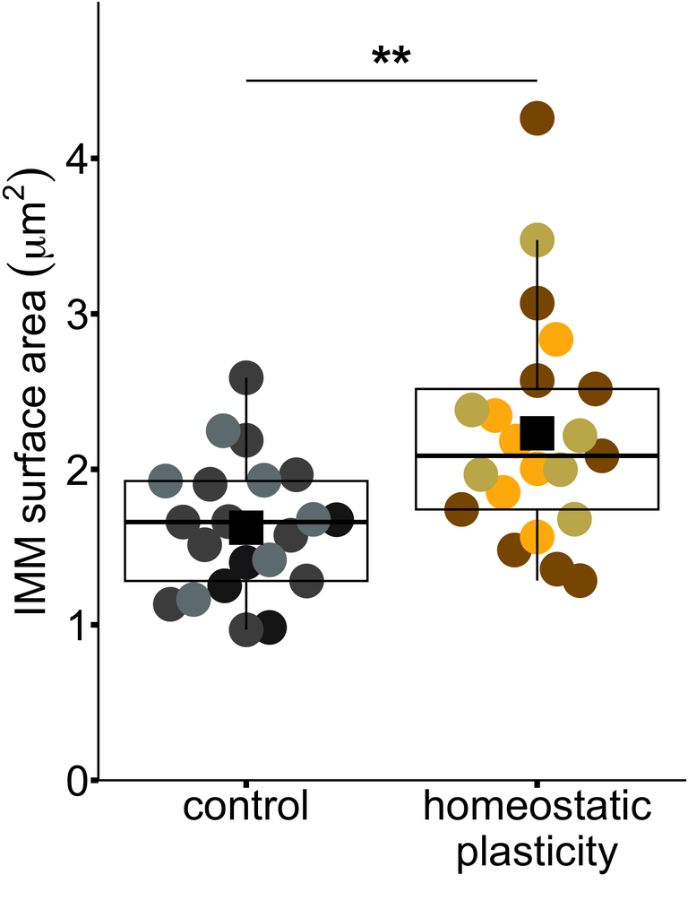

```r
set.seed(20261109)
p_to_stars <- function(p) case_when(
  p < 0.0001 ~ "****", p < 0.001 ~ "***",
  p < 0.01 ~ "**", p < 0.05 ~ "*", TRUE ~ "ns"
)

test_results <- tibble(
  group1_x = spacing_map["Control"],
  group2_x = spacing_map["TTX"],
  y_position = 4.5,
  stars = p_to_stars(condition_p)
) %>%
  filter(stars != "ns")

date_levels <- levels(Density$Date)

date_colors <- c(
  setNames(rep(c("#1A1A1A", "#4D4D4D", "#6F7C80"), length.out = length(date_levels)),
           paste("Control", date_levels, sep = "_")),
  setNames(rep(c("#8A5700", "#FFB703", "#C5B358"), length.out = length(date_levels)),
           paste("TTX", date_levels, sep = "_"))
)

fig3d_plot <- ggplot(Density, aes(x_pos, IMM_surf_um2, color = color_key)) +
  ggbeeswarm::geom_beeswarm(cex = 8, priority = "random", size = 30,
                            alpha = 1, corral = "random") +
  geom_boxplot(aes(group = x_pos), fill = NA, width = 1, outlier.shape = NA,
               linewidth = 2, color = "black") +
  stat_summary(aes(group = x_pos), fun = mean, geom = "point",
               shape = 15, size = 30, color = "black") +
  geom_segment(data = test_results,
               aes(x = group1_x, xend = group2_x, y = y_position, yend = y_position),
               inherit.aes = FALSE, linewidth = 2, color = "black") +
  geom_text(data = test_results,
            aes(x = (group1_x + group2_x) / 2, y = y_position + 0.1, label = stars),
            inherit.aes = FALSE, size = 35, color = "black", fontface = "bold") +
  scale_x_continuous(breaks = unname(spacing_map),
                     labels = c("control", "homeostatic\nplasticity")) +
  scale_color_manual(values = date_colors) +
  scale_y_continuous(oob = scales::oob_keep, breaks = c(0, 1, 2, 3, 4), limits = c(0, 5), expand = c(0, 0)) +
  labs(x = "", y = expression(IMM~surface~area~group("(", mu*m^2, ")"))) +
  theme_classic() +
  theme(
    axis.title = element_text(size = 80, color = "black"),
    axis.text = element_text(size = 80, color = "black"),
    axis.ticks = element_line(linewidth = 5, color = "black"),
    axis.ticks.length = grid::unit(0.5, "cm"),
    axis.line = element_line(linewidth = 2, color = "black"),
    legend.position = "none"
  )

fig3d_plot
```

# Fig 3E

Cristae membrane (CM) surface area in reconstructed juxtaspinal mitochondrial regions.

**Source data**  
`Fig 3D, E.csv`

**Columns**

- `Date` — Experiment date
- `Condition` — Control or TTX
- `Mito` — Mitochondrial reconstruction ID
- `CM_surf_um2` — Crista membrane surface area (µm²)

## Data

```r
condition_order <- c("Control", "TTX")
spacing_map <- c("Control" = 1, "TTX" = 2.2)

Density <- read_csv("./Fig 3D, E.csv", show_col_types = FALSE) %>%
  filter(Condition %in% condition_order) %>%
  mutate(
    Condition = factor(Condition, levels = condition_order),
    Date = factor(trimws(as.character(Date))),
    CM_surf_um2 = as.numeric(CM_surf_um2),
    x_pos = unname(spacing_map[as.character(Condition)]),
    color_key = paste(Condition, Date, sep = "_")
  ) %>%
  filter(is.finite(CM_surf_um2))

if (nrow(Density) == 0) stop("No valid observations remain.")

Density %>%
  mutate(across(where(is.numeric), ~ round(.x, 3)))
```

| Date | Condition | Mito | OMM_vol_um3 | OMM_surf_um2 | CM_surf_um2 | CM_highk1_um2 | IMM_surf_um2 | x_pos | color_key |
| --- | --- | --- | --- | --- | --- | --- | --- | --- | --- |
| 2022-08-10 | Control | 1 | 0.046 | 0.524 | 0.908 | 0.190 | 1.401 | 1.0 | Control_2022-08-10 |
| 2022-08-10 | Control | 2 | 0.035 | 0.487 | 0.579 | 0.121 | 0.983 | 1.0 | Control_2022-08-10 |
| 2022-08-10 | Control | 3 | 0.058 | 0.557 | 1.135 | 0.233 | 1.676 | 1.0 | Control_2022-08-10 |
| 2022-08-10 | Control | 4 | 0.047 | 0.560 | 0.716 | 0.172 | 1.251 | 1.0 | Control_2022-08-10 |
| 2022-08-10 | TTX | 1 | 0.045 | 0.629 | 1.244 | 0.296 | 1.742 | 2.2 | TTX_2022-08-10 |
| 2022-08-10 | TTX | 2 | 0.115 | 1.882 | 2.861 | 0.607 | 4.258 | 2.2 | TTX_2022-08-10 |
| 2022-08-10 | TTX | 3 | 0.056 | 0.642 | 1.623 | 0.428 | 2.087 | 2.2 | TTX_2022-08-10 |
| 2022-08-10 | TTX | 4 | 0.081 | 1.765 | 1.825 | 0.380 | 3.069 | 2.2 | TTX_2022-08-10 |
| 2022-08-10 | TTX | 5 | 0.037 | 0.858 | 0.669 | 0.221 | 1.284 | 2.2 | TTX_2022-08-10 |
| 2022-08-10 | TTX | 6 | 0.072 | 1.277 | 1.375 | 0.311 | 2.517 | 2.2 | TTX_2022-08-10 |

[output cut: 32 more lines]

## Summary

```r
summary_table <- Density %>%
  group_by(Condition) %>%
  summarise(
    n_Mitochondria = n(),
    n_Experiment_Dates = n_distinct(Date),
    `Mean (SE)` = sprintf("%.3f (%.3f)", mean(CM_surf_um2), sd(CM_surf_um2) / sqrt(n())),
    .groups = "drop"
  )

summary_table
```

| Condition | n_Mitochondria | n_Experiment_Dates | Mean (SE) |
| --- | --- | --- | --- |
| Control | 21 | 3 | 1.063 (0.075) |
| TTX | 21 | 3 | 1.487 (0.112) |

## Statistics

Two-way ANOVA with condition, experiment date, and their interaction (Type I sums of squares).

```r
fit_aov <- aov(CM_surf_um2 ~ Condition * Date, data = Density)
anova_table <- anova(fit_aov)
condition_p <- as.numeric(anova_table["Condition", "Pr(>F)"])
format_p <- function(p) ifelse(p < 0.0001, "<0.0001", sprintf("%.4f", p))

group_means <- Density %>%
  group_by(Condition) %>%
  summarise(mean = mean(CM_surf_um2), SE = sd(CM_surf_um2) / sqrt(n()), .groups = "drop")

stats_table <- tibble(
  Test = "Two-way ANOVA",
  Comparison = "Control vs TTX",
  `Control mean (SE)` = sprintf("%.3f (%.3f)", group_means$mean[1], group_means$SE[1]),
  `TTX mean (SE)` = sprintf("%.3f (%.3f)", group_means$mean[2], group_means$SE[2]),
  `Condition p` = format_p(condition_p)
)

stats_table
```

| Test | Comparison | Control mean (SE) | TTX mean (SE) | Condition p |
| --- | --- | --- | --- | --- |
| Two-way ANOVA | Control vs TTX | 1.063 (0.075) | 1.487 (0.112) | 0.0038 |

## Plot

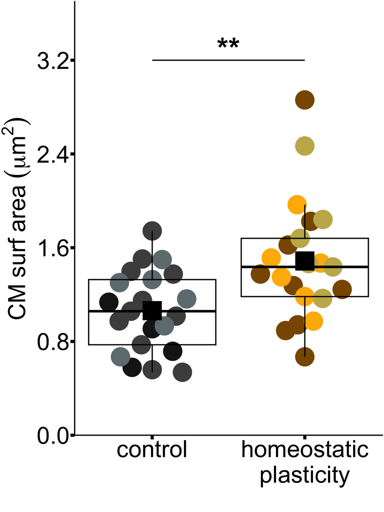

```r
set.seed(20261109)
p_to_stars <- function(p) case_when(
  p < 0.0001 ~ "****", p < 0.001 ~ "***",
  p < 0.01 ~ "**", p < 0.05 ~ "*", TRUE ~ "ns"
)

test_results <- tibble(
  group1_x = spacing_map["Control"],
  group2_x = spacing_map["TTX"],
  y_position = 3.2,
  stars = p_to_stars(condition_p)
) %>%
  filter(stars != "ns")

date_levels <- levels(Density$Date)

date_colors <- c(
  setNames(rep(c("#1A1A1A", "#4D4D4D", "#6F7C80"), length.out = length(date_levels)),
           paste("Control", date_levels, sep = "_")),
  setNames(rep(c("#8A5700", "#FFB703", "#C5B358"), length.out = length(date_levels)),
           paste("TTX", date_levels, sep = "_"))
)

fig3e_plot <- ggplot(Density, aes(x_pos, CM_surf_um2, color = color_key)) +
  ggbeeswarm::geom_beeswarm(cex = 8, priority = "random", size = 30,
                            alpha = 1, corral = "random") +
  geom_boxplot(aes(group = x_pos), fill = NA, width = 1, outlier.shape = NA,
               linewidth = 2, color = "black") +
  stat_summary(aes(group = x_pos), fun = mean, geom = "point",
               shape = 15, size = 30, color = "black") +
  geom_segment(data = test_results,
               aes(x = group1_x, xend = group2_x, y = y_position, yend = y_position),
               inherit.aes = FALSE, linewidth = 2, color = "black") +
  geom_text(data = test_results,
            aes(x = (group1_x + group2_x) / 2, y = y_position + 0.1, label = stars),
            inherit.aes = FALSE, size = 35, color = "black", fontface = "bold") +
  scale_x_continuous(breaks = unname(spacing_map),
                     labels = c("control", "homeostatic\nplasticity")) +
  scale_color_manual(values = date_colors) +
  scale_y_continuous(oob = scales::oob_keep,
    breaks = c(0, 0.8, 1.6, 2.4, 3.2),
    limits = c(0, 3.7),
    expand = c(0, 0)
  ) +
  labs(x = "", y = expression(CM~surf~area~group("(", mu*m^2, ")"))) +
  theme_classic() +
  theme(
    axis.title = element_text(size = 80, color = "black"),
    axis.text = element_text(size = 80, color = "black"),
    axis.ticks = element_line(linewidth = 5, color = "black"),
    axis.ticks.length = grid::unit(0.5, "cm"),
    axis.line = element_line(linewidth = 2, color = "black"),
    legend.position = "none"
  )

fig3e_plot
```

# Fig 3F

Number of crista junctions within each reconstructed juxtaspinal mitochondrial region.

**Source data**  
`Fig 3D, E.csv`, `Fig 3F.csv`

**Columns**

- `Date` — Experiment date
- `Condition` — Control or TTX
- `Mito` — Mitochondrial reconstruction ID
- `Junction_ID` — Crista junction ID

## Data

Distinct junctions are counted per reconstruction. Reconstructions with no junctions contribute a count of zero.

```r
condition_order <- c("Control", "TTX")
spacing_map <- c("Control" = 1, "TTX" = 2.2)

reconstructions <- read_csv("./Fig 3D, E.csv", show_col_types=FALSE) %>%
  distinct(Date,Condition,Mito) %>% filter(Condition %in% condition_order)
junction_counts <- read_csv("./Fig 3F.csv",show_col_types=FALSE) %>%
  filter(Condition %in% condition_order,!is.na(Date),!is.na(Mito),!is.na(Junction_ID)) %>%
  distinct(Date,Condition,Mito,Junction_ID) %>% count(Date,Condition,Mito,name="CJ_count")
Density <- reconstructions %>% left_join(junction_counts,by=c("Date","Condition","Mito")) %>%
  mutate(CJ_count=coalesce(CJ_count,0L),Condition=factor(Condition,levels=condition_order),
         Date=factor(trimws(as.character(Date))),Mito=as.character(Mito),
         x_pos=unname(spacing_map[as.character(Condition)]),color_key=paste(Condition,Date,sep="_"))

if (nrow(Density) == 0) stop("No valid observations remain.")

Density %>%
  mutate(across(where(is.numeric), ~ round(.x, 3)))
```

| Date | Condition | Mito | CJ_count | x_pos | color_key |
| --- | --- | --- | --- | --- | --- |
| 2022-08-10 | Control | 1 | 30 | 1.0 | Control_2022-08-10 |
| 2022-08-10 | Control | 2 | 27 | 1.0 | Control_2022-08-10 |
| 2022-08-10 | Control | 3 | 71 | 1.0 | Control_2022-08-10 |
| 2022-08-10 | Control | 4 | 42 | 1.0 | Control_2022-08-10 |
| 2022-08-10 | TTX | 1 | 86 | 2.2 | TTX_2022-08-10 |
| 2022-08-10 | TTX | 2 | 198 | 2.2 | TTX_2022-08-10 |
| 2022-08-10 | TTX | 3 | 83 | 2.2 | TTX_2022-08-10 |
| 2022-08-10 | TTX | 4 | 164 | 2.2 | TTX_2022-08-10 |
| 2022-08-10 | TTX | 5 | 69 | 2.2 | TTX_2022-08-10 |
| 2022-08-10 | TTX | 6 | 130 | 2.2 | TTX_2022-08-10 |

[output cut: 32 more lines]

## Summary

```r
summary_table <- Density %>%
  group_by(Condition) %>%
  summarise(
    n_Mitochondria = n(),
    n_Experiment_Dates = n_distinct(Date),
    `Mean (SE)` = sprintf("%.3f (%.3f)", mean(CJ_count), sd(CJ_count) / sqrt(n())),
    .groups = "drop"
  )

summary_table
```

| Condition | n_Mitochondria | n_Experiment_Dates | Mean (SE) |
| --- | --- | --- | --- |
| Control | 21 | 3 | 60.095 (4.704) |
| TTX | 21 | 3 | 88.857 (8.173) |

## Statistics

Two-way ANOVA with condition, experiment date, and their interaction (Type I sums of squares).

```r
fit_aov <- aov(CJ_count ~ Condition * Date, data = Density)
anova_table <- anova(fit_aov)
condition_p <- as.numeric(anova_table["Condition", "Pr(>F)"])
format_p <- function(p) ifelse(p < 0.0001, "<0.0001", sprintf("%.4f", p))

group_means <- Density %>%
  group_by(Condition) %>%
  summarise(mean = mean(CJ_count), SE = sd(CJ_count) / sqrt(n()), .groups = "drop")

stats_table <- tibble(
  Test = "Two-way ANOVA",
  Comparison = "Control vs TTX",
  `Control mean (SE)` = sprintf("%.3f (%.3f)", group_means$mean[1], group_means$SE[1]),
  `TTX mean (SE)` = sprintf("%.3f (%.3f)", group_means$mean[2], group_means$SE[2]),
  `Condition p` = format_p(condition_p)
)

stats_table
```

| Test | Comparison | Control mean (SE) | TTX mean (SE) | Condition p |
| --- | --- | --- | --- | --- |
| Two-way ANOVA | Control vs TTX | 60.095 (4.704) | 88.857 (8.173) | 0.0009 |

## Plot

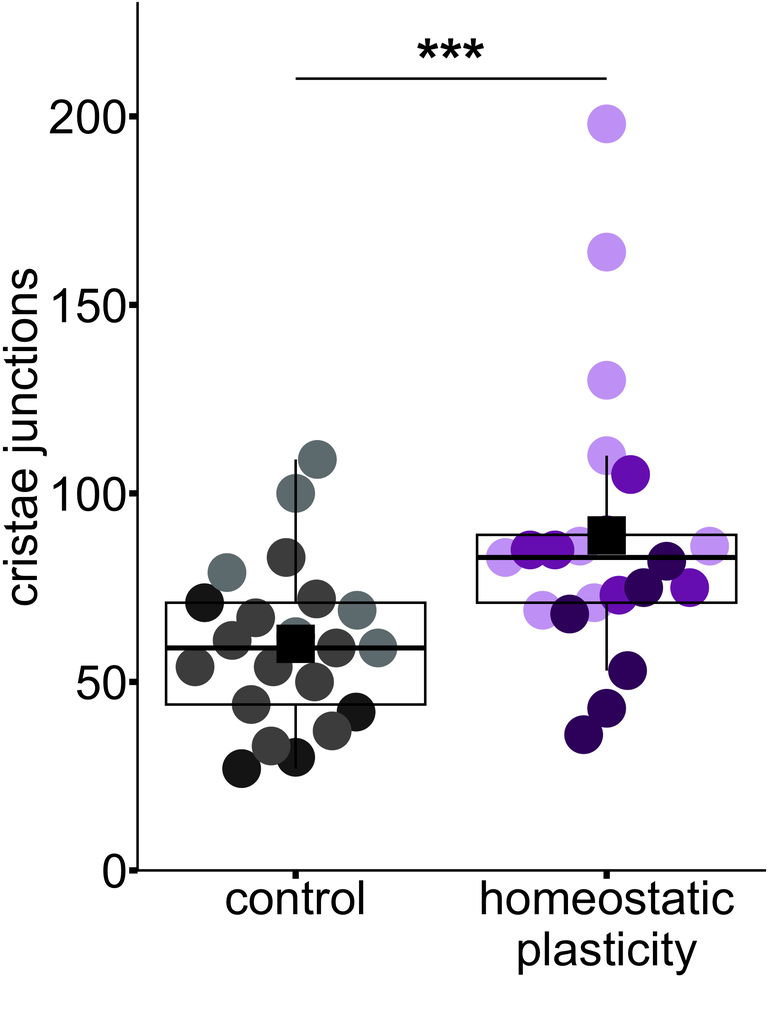

```r
set.seed(20261109)
p_to_stars <- function(p) case_when(
  p < 0.0001 ~ "****", p < 0.001 ~ "***",
  p < 0.01 ~ "**", p < 0.05 ~ "*", TRUE ~ "ns"
)

test_results <- tibble(
  group1_x = spacing_map["Control"],
  group2_x = spacing_map["TTX"],
  y_position = 210,
  stars = p_to_stars(condition_p)
) %>%
  filter(stars != "ns")

date_levels <- levels(Density$Date)

date_colors <- c(
  setNames(rep(c("#1A1A1A", "#4D4D4D", "#6F7C80"), length.out = length(date_levels)),
           paste("Control", date_levels, sep = "_")),
  setNames(rep(c("#CBA6F7", "#7B2CBF", "#3C096C"), length.out = length(date_levels)),
           paste("TTX", date_levels, sep = "_"))
)

fig3f_plot <- ggplot(Density, aes(x_pos, CJ_count, color = color_key)) +
  ggbeeswarm::geom_beeswarm(cex = 8, priority = "random", size = 30,
                            alpha = 1, corral = "random") +
  geom_boxplot(aes(group = x_pos), fill = NA, width = 1, outlier.shape = NA,
               linewidth = 2, color = "black") +
  stat_summary(aes(group = x_pos), fun = mean, geom = "point",
               shape = 15, size = 30, color = "black") +
  geom_segment(data = test_results,
               aes(x = group1_x, xend = group2_x, y = y_position, yend = y_position),
               inherit.aes = FALSE, linewidth = 2, color = "black") +
  geom_text(data = test_results,
            aes(x = (group1_x + group2_x) / 2, y = y_position + 5, label = stars),
            inherit.aes = FALSE, size = 35, color = "black", fontface = "bold") +
  scale_x_continuous(breaks = unname(spacing_map),
                     labels = c("control", "homeostatic\nplasticity")) +
  scale_color_manual(values = date_colors) +
  scale_y_continuous(oob = scales::oob_keep,
    breaks = c(0, 50, 100, 150, 200),
    limits = c(0, 230),
    expand = c(0, 0)
  ) +
  labs(x = "", y = "cristae junctions") +
  theme_classic() +
  theme(
    axis.title = element_text(size = 80, color = "black"),
    axis.text = element_text(size = 80, color = "black"),
    axis.ticks = element_line(linewidth = 5, color = "black"),
    axis.ticks.length = grid::unit(0.5, "cm"),
    axis.line = element_line(linewidth = 2, color = "black"),
    legend.position = "none"
  )

fig3f_plot
```

# Fig 3H

Surface area of high-curvature cristae membrane in reconstructed juxtaspinal mitochondrial regions.

**Source data**  
`Fig 3H.csv`

**Columns**

- `Date` — Experiment date
- `Condition` — Control or TTX
- `Mito` — Mitochondrial reconstruction ID
- `CM_highk1_um2` — Crista membrane area at high principal curvature (µm²)

## Data

High curvature corresponds to first principal curvature greater than 80 µm⁻¹.

```r
condition_order <- c("Control", "TTX")
spacing_map <- c("Control" = 1, "TTX" = 2.2)

Density <- read_csv("./Fig 3H.csv", show_col_types = FALSE) %>%
  filter(Condition %in% condition_order) %>%
  mutate(
    Condition = factor(Condition, levels = condition_order),
    Date = factor(trimws(as.character(Date))),
    CM_highk1_um2 = as.numeric(CM_highk1_um2),
    x_pos = unname(spacing_map[as.character(Condition)]),
    color_key = paste(Condition, Date, sep = "_")
  ) %>%
  filter(is.finite(CM_highk1_um2))

if (nrow(Density) == 0) stop("No valid observations remain.")

Density %>%
  mutate(across(where(is.numeric), ~ round(.x, 3)))
```

| Date | Condition | Mito | OMM_vol_um3 | CM_surf_um2 | CM_highk1_um2 | x_pos | color_key |
| --- | --- | --- | --- | --- | --- | --- | --- |
| 2022-08-10 | Control | 1 | 0.046 | 0.908 | 0.190 | 1.0 | Control_2022-08-10 |
| 2022-08-10 | Control | 2 | 0.035 | 0.579 | 0.121 | 1.0 | Control_2022-08-10 |
| 2022-08-10 | Control | 3 | 0.058 | 1.135 | 0.233 | 1.0 | Control_2022-08-10 |
| 2022-08-10 | Control | 4 | 0.047 | 0.716 | 0.172 | 1.0 | Control_2022-08-10 |
| 2023-01-04 | Control | 5 | 0.046 | 1.016 | 0.231 | 1.0 | Control_2023-01-04 |
| 2023-01-04 | Control | 6 | 0.073 | 1.743 | 0.482 | 1.0 | Control_2023-01-04 |
| 2023-01-04 | Control | 7 | 0.048 | 1.058 | 0.304 | 1.0 | Control_2023-01-04 |
| 2023-01-04 | Control | 8 | 0.057 | 1.398 | 0.282 | 1.0 | Control_2023-01-04 |
| 2023-01-04 | Control | 9 | 0.040 | 0.975 | 0.347 | 1.0 | Control_2023-01-04 |
| 2023-01-04 | Control | 10 | 0.027 | 0.559 | 0.164 | 1.0 | Control_2023-01-04 |

[output cut: 32 more lines]

## Summary

```r
summary_table <- Density %>%
  group_by(Condition) %>%
  summarise(
    n_Mitochondria = n(),
    n_Experiment_Dates = n_distinct(Date),
    `Mean (SE)` = sprintf("%.3f (%.3f)", mean(CM_highk1_um2), sd(CM_highk1_um2) / sqrt(n())),
    .groups = "drop"
  )

summary_table
```

| Condition | n_Mitochondria | n_Experiment_Dates | Mean (SE) |
| --- | --- | --- | --- |
| Control | 21 | 3 | 0.276 (0.019) |
| TTX | 21 | 3 | 0.349 (0.020) |

## Statistics

Two-way ANOVA with condition, experiment date, and their interaction (Type I sums of squares).

```r
fit_aov <- aov(CM_highk1_um2 ~ Condition * Date, data = Density)
anova_table <- anova(fit_aov)
condition_p <- as.numeric(anova_table["Condition", "Pr(>F)"])
format_p <- function(p) ifelse(p < 0.0001, "<0.0001", sprintf("%.4f", p))

group_means <- Density %>%
  group_by(Condition) %>%
  summarise(mean = mean(CM_highk1_um2), SE = sd(CM_highk1_um2) / sqrt(n()), .groups = "drop")

stats_table <- tibble(
  Test = "Two-way ANOVA",
  Comparison = "Control vs TTX",
  `Control mean (SE)` = sprintf("%.3f (%.3f)", group_means$mean[1], group_means$SE[1]),
  `TTX mean (SE)` = sprintf("%.3f (%.3f)", group_means$mean[2], group_means$SE[2]),
  `Condition p` = format_p(condition_p)
)

stats_table
```

| Test | Comparison | Control mean (SE) | TTX mean (SE) | Condition p |
| --- | --- | --- | --- | --- |
| Two-way ANOVA | Control vs TTX | 0.276 (0.019) | 0.349 (0.020) | 0.0097 |

## Plot

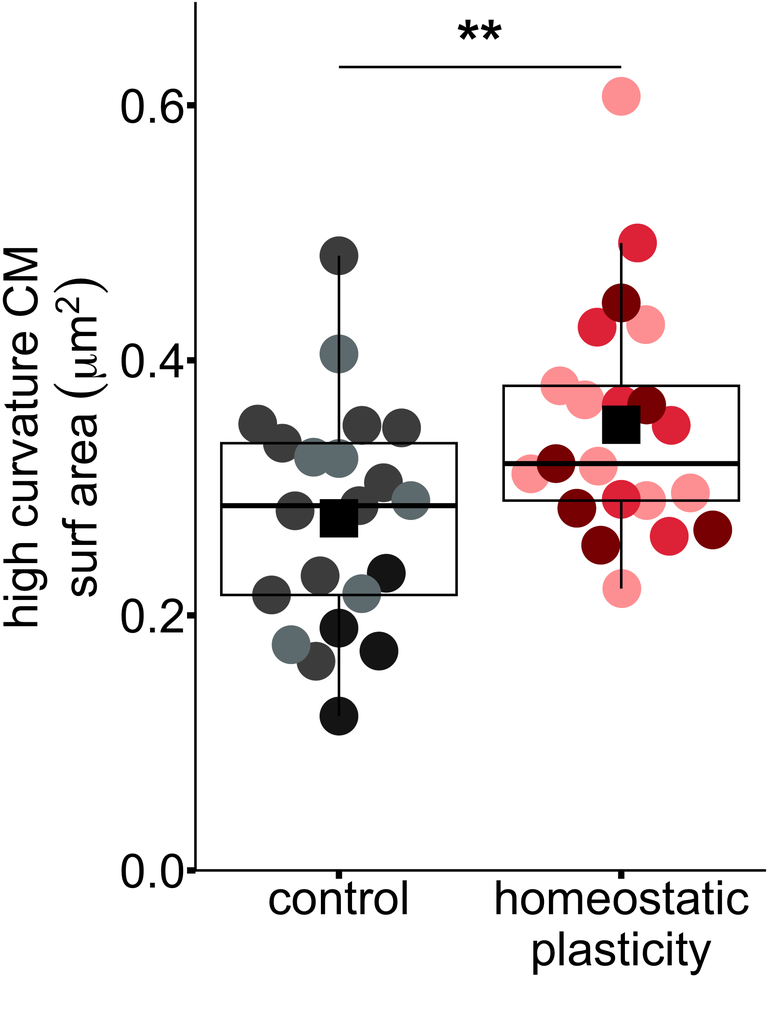

```r
set.seed(20261109)
p_to_stars <- function(p) case_when(
  p < 0.0001 ~ "****", p < 0.001 ~ "***",
  p < 0.01 ~ "**", p < 0.05 ~ "*", TRUE ~ "ns"
)

test_results <- tibble(
  group1_x = spacing_map["Control"],
  group2_x = spacing_map["TTX"],
  y_position = 0.63,
  stars = p_to_stars(condition_p)
) %>%
  filter(stars != "ns")

date_levels <- levels(Density$Date)

date_colors <- c(
  setNames(rep(c("#1A1A1A", "#4D4D4D", "#6F7C80"), length.out = length(date_levels)),
           paste("Control", date_levels, sep = "_")),
  setNames(rep(c("#FFA3A3", "#E63946", "#8B0000"), length.out = length(date_levels)),
           paste("TTX", date_levels, sep = "_"))
)

fig3h_plot <- ggplot(Density, aes(x_pos, CM_highk1_um2, color = color_key)) +
  ggbeeswarm::geom_beeswarm(cex = 9, priority = "random", size = 30,
                            alpha = 1, corral = "random") +
  geom_boxplot(aes(group = x_pos), fill = NA, width = 1, outlier.shape = NA,
               linewidth = 2, color = "black") +
  stat_summary(aes(group = x_pos), fun = mean, geom = "point",
               shape = 15, size = 30, color = "black") +
  geom_segment(data = test_results,
               aes(x = group1_x, xend = group2_x, y = y_position, yend = y_position),
               inherit.aes = FALSE, linewidth = 2, color = "black") +
  geom_text(data = test_results,
            aes(x = (group1_x + group2_x) / 2, y = y_position + 0.02, label = stars),
            inherit.aes = FALSE, size = 35, color = "black", fontface = "bold") +
  scale_x_continuous(breaks = unname(spacing_map),
                     labels = c("control", "homeostatic\nplasticity")) +
  scale_color_manual(values = date_colors) +
  scale_y_continuous(oob = scales::oob_keep,
    breaks = c(0, 0.2, 0.4, 0.6),
    limits = c(0, 0.68),
    expand = c(0, 0)
  ) +
  labs(
    x = "",
    y = expression(atop(high~curvature~CM, surf~area~group("(", mu*m^2, ")")))
  ) +
  theme_classic() +
  theme(
    axis.title = element_text(size = 80, color = "black"),
    axis.text = element_text(size = 80, color = "black"),
    axis.ticks = element_line(linewidth = 5, color = "black"),
    axis.ticks.length = grid::unit(0.5, "cm"),
    axis.line = element_line(linewidth = 2, color = "black"),
    legend.position = "none"
  )

fig3h_plot
```